# Move Classification Error Analysis: Nominal Regression Modeling

Ziwei Zhou

12/16/2020

Frist we define several helper functions:

```r
library(ggplot2)
library(nnet)
library(tidyverse)
library(rockchalk)
library(ggplot2)
library(caret)
library(mlogit)
```

```r
###################
# 1. Preprocessing
###################
# six conditions due human anntator's inconsistency
preprocess <- function(path, down_sample=FALSE){
  dat <- read.csv(path)
  dat <-dat %>% filter(Error.Code.3..Human.!="")
  dat<-dat %>% filter(pre.OR.difference!=9999)
  dat<- dat %>% filter(pre.OR.difference!=-9999)
  dat<- dat %>% filter(pre.OR.difference!="NA")
  if (grepl('AM1_PM2', path, fixed = TRUE)) {
    dat$Error.Code.3..Human.<- combineLevels(dat$Error.Code.3..Human., levs = c("indicative AM","semi-indicative AM"), newLabel = "indicative_AM")
    dat$Error.Code.3..Human.<- combineLevels(dat$Error.Code.3..Human., levs = c("indicative MM","semi-indicative MM"), newLabel = "indicative_MM")
    dat$Error.Code.3..Human.<- combineLevels(dat$Error.Code.3..Human., levs = c("non-indicative", "non-indicative "), newLabel = "non_indicative")
    dat_sub <- dat %>%
      filter(Error.Code.3..Human.=='indicative_AM'|Error.Code.3..Human.== 'indicative_MM'|Error.Code.3..Human.=='non_indicative')
    dat_sub$Error.Code.3..Human. <-as.factor(droplevels(dat_sub$Error.Code.3..Human.))
    dat_sub2 <- dat_sub %>% select(doc,feature,text,pre.OR_m1,pre.OR_m2,pre.OR.difference,post.feature_weight,Error.Code.3..Human.)
    dat_sub2 <- dat_sub2[!duplicated(dat_sub2$feature), ]
    dat_sub3 <- downSample(x = dat_sub2, y = dat_sub2$Error.Code.3..Human.) # ** may also try up-sampling?**
    if (down_sample) {
      return(dat_sub3)
    }
    else {
      return(dat_sub2)
    }
  }
  if (grepl('AM1_PM3', path, fixed = TRUE)) {
    dat$Error.Code.3..Human.<- combineLevels(dat$Error.Code.3..Human., levs = c("indicative AM"), newLabel = "indicative_AM")
    dat$Error.Code.3..Human.<- combineLevels(dat$Error.Code.3..Human., levs = c("indicative MM","semi-indicative MM"), newLabel = "indicative_MM")
    dat$Error.Code.3..Human.<- combineLevels(dat$Error.Code.3..Human., levs = c("non-indicative"), newLabel = "non_indicative")
    dat_sub <- dat %>%
      filter(Error.Code.3..Human.=='indicative_AM'|Error.Code.3..Human.== 'indicative_MM'|Error.Code.3..Human.=='non_indicative')
    dat_sub$Error.Code.3..Human. <-as.factor(droplevels(dat_sub$Error.Code.3..Human.))
    dat_sub2 <- dat_sub %>% select(doc,feature,text,pre.OR_m1,pre.OR_m3,pre.OR.difference,post.feature_weight,Error.Code.3..Human.)
    dat_sub2 <- dat_sub2[!duplicated(dat_sub2$feature), ]
    dat_sub3 <- downSample(x = dat_sub2, y = dat_sub2$Error.Code.3..Human.) # ** may also try up-sampling?**
    if (down_sample) {
      return(dat_sub3)
    }
    else {
      return(dat_sub2)
    }
  }
  if (grepl('AM2_PM1', path, fixed = TRUE)) {
    dat$Error.Code.3..Human.<- combineLevels(dat$Error.Code.3..Human., levs = c("indicative AM","semi-indicative AM","indicative AM "), newLabel = "indicative_AM")
    dat$Error.Code.3..Human.<- combineLevels(dat$Error.Code.3..Human., levs = c("indicative MM","semi-indicative MM"), newLabel = "indicative_MM")
    dat$Error.Code.3..Human.<- combineLevels(dat$Error.Code.3..Human., levs = c("non-indicative"), newLabel = "non_indicative")
    dat_sub <- dat %>%
      filter(Error.Code.3..Human.=='indicative_AM'|Error.Code.3..Human.== 'indicative_MM'|Error.Code.3..Human.=='non_indicative')
    dat_sub$Error.Code.3..Human. <-as.factor(droplevels(dat_sub$Error.Code.3..Human.))
    dat_sub2 <- dat_sub %>% select(doc,feature,text,pre.OR_m1,pre.OR_m2,pre.OR.difference,post.feature_weight,Error.Code.3..Human.)
    dat_sub2 <- dat_sub2[!duplicated(dat_sub2$feature), ]
    dat_sub3 <- downSample(x = dat_sub2, y = dat_sub2$Error.Code.3..Human.) # ** may also try up-sampling?**
    if (down_sample) {
      return(dat_sub3)
    }
    else {
      return(dat_sub2)
    }
  }
  if (grepl('AM2_PM3', path, fixed = TRUE)) {
    dat$Error.Code.3..Human.<- combineLevels(dat$Error.Code.3..Human., levs = c("indicative AM","semi-indicative AM","indicative AM "), newLabel = "indicative_AM")
    dat$Error.Code.3..Human.<- combineLevels(dat$Error.Code.3..Human., levs = c("indicative MM","semi-indicative MM"), newLabel = "indicative_MM")
    dat$Error.Code.3..Human.<- combineLevels(dat$Error.Code.3..Human., levs = c("non-indicative"), newLabel = "non_indicative")
    dat_sub <- dat %>%
      filter(Error.Code.3..Human.=='indicative_AM'|Error.Code.3..Human.== 'indicative_MM'|Error.Code.3..Human.=='non_indicative')
    dat_sub$Error.Code.3..Human. <-as.factor(droplevels(dat_sub$Error.Code.3..Human.))
    dat_sub2 <- dat_sub %>% select(doc,feature,text,pre.OR_m3,pre.OR_m2,pre.OR.difference,post.feature_weight,Error.Code.3..Human.)
    dat_sub2 <- dat_sub2[!duplicated(dat_sub2$feature), ]
    dat_sub3 <- downSample(x = dat_sub2, y = dat_sub2$Error.Code.3..Human.) # ** may also try up-sampling?**
    if (down_sample) {
      return(dat_sub3)
    }
    else {
      return(dat_sub2)
    }
  }
  if (grepl('AM3_PM1', path, fixed = TRUE)) {
    dat$Error.Code.3..Human.<- combineLevels(dat$Error.Code.3..Human., levs = c("indicative AM", "semi-indicative AM"), newLabel = "indicative_AM")
    dat$Error.Code.3..Human.<- combineLevels(dat$Error.Code.3..Human., levs = c("indicative MM"), newLabel = "indicative_MM")
    dat$Error.Code.3..Human.<- combineLevels(dat$Error.Code.3..Human., levs = c("non-indicative", "non-indicative "), newLabel = "non_indicative")
    dat_sub <- dat %>%
      filter(Error.Code.3..Human.=='indicative_AM'|Error.Code.3..Human.== 'indicative_MM'|Error.Code.3..Human.=='non_indicative')
    dat_sub$Error.Code.3..Human. <-as.factor(droplevels(dat_sub$Error.Code.3..Human.))
    dat_sub2 <- dat_sub %>% select(doc,feature,text,pre.OR_m1,pre.OR_m3,pre.OR.difference,post.feature_weight,Error.Code.3..Human.)
    dat_sub2 <- dat_sub2[!duplicated(dat_sub2$feature), ]
    dat_sub3 <- downSample(x = dat_sub2, y = dat_sub2$Error.Code.3..Human.) # ** may also try up-sampling?**
    if (down_sample) {
      return(dat_sub3)
    }
    else {
      return(dat_sub2)
    }
  }
  if (grepl('AM3_PM2', path, fixed = TRUE)) {
    dat$Error.Code.3..Human.<- combineLevels(dat$Error.Code.3..Human., levs = c("indicative AM", "semi-indicative AM"), newLabel = "indicative_AM")
    dat$Error.Code.3..Human.<- combineLevels(dat$Error.Code.3..Human., levs = c("indicative MM", "semi-indicative MM"), newLabel = "indicative_MM")
    dat$Error.Code.3..Human.<- combineLevels(dat$Error.Code.3..Human., levs = c("non-indicative"), newLabel = "non_indicative")
    dat_sub <- dat %>%
      filter(Error.Code.3..Human.=='indicative_AM'|Error.Code.3..Human.== 'indicative_MM'|Error.Code.3..Human.=='non_indicative')
    dat_sub$Error.Code.3..Human. <-as.factor(droplevels(dat_sub$Error.Code.3..Human.))
    dat_sub2 <- dat_sub %>% select(doc,feature,text,pre.OR_m3,pre.OR_m2,pre.OR.difference,post.feature_weight,Error.Code.3..Human.)
    dat_sub2 <- dat_sub2[!duplicated(dat_sub2$feature), ]
    dat_sub3 <- downSample(x = dat_sub2, y = dat_sub2$Error.Code.3..Human.) # ** may also try up-sampling?**
    if (down_sample) {
      return(dat_sub3)
    }
    else {
      return(dat_sub2)
    }
  }

}


###################
# 2. Modeling
###################
nominals <- function(dat, null=FALSE, pre=FALSE, post=FALSE, prepost=FALSE, full=FALSE) {
  dat$Error.Code.3..Human. <- relevel(dat$Error.Code.3..Human., ref = "non_indicative")
  if (null) {
    null.mod<-  multinom(Error.Code.3..Human. ~ 1, data = dat)
    return(null.mod)
  }
  if (pre) {
    pre.odds.mod <- multinom(Error.Code.3..Human. ~ pre.OR.difference, data = dat)
    return(pre.odds.mod)
  }
  if (post) {
    post.weights.mod <- multinom(Error.Code.3..Human. ~ post.feature_weight, data = dat)
    return(post.weights.mod)
  }
  if (prepost) {
    pre.post.mod <- multinom(Error.Code.3..Human. ~ pre.OR.difference + post.feature_weight, data = dat)
    return(pre.post.mod)
  }
  if (full) {
    full.mod<- multinom(Error.Code.3..Human. ~ pre.OR.difference + post.feature_weight + pre.OR.difference:post.feature_weight, data = dat)
    return(full.mod)
  }
}

###################
# 3. Plotting
###################
# currently only supports pre.odds.mod
prob_plot <- function(mod, dat) {
  p_pre <- predict(mod, type="probs", newdata=dat)
  p_indicative_AM <- data.frame(p_pre)$indicative_AM
  p_indicative_MM <- data.frame(p_pre)$indicative_MM
  p_non_indicative <- data.frame(p_pre)$non_indicative
  x <- dat$pre.OR.difference
  plot_data <- data.frame(cbind(x,p_indicative_AM,p_indicative_MM,p_non_indicative))
  ggplot(data=plot_data) +
    xlim(-25,25) +
    geom_line(aes(x=x,y=p_indicative_AM, color="indicative AM")) +
    geom_line(aes(x=x,y=p_indicative_MM, color="indicative MM")) +
    geom_line(aes(x=x,y=p_non_indicative, color="non-indicative")) +
    scale_color_manual(name = "Human Coding Categories",
                       values = c("indicative AM" = "blue", "indicative MM" = "red", "non-indicative" = "black")) +
    ggtitle("Predicted Probabilities Plots for Pre-Odds Ratio Difference") + xlab("Log Odds Ratio Difference") + ylab("Predicted Probabilities")
}

###################
# 4. Performance
###################
eval_train <- function(dat_sub3) {
  pre.odds.mod <- multinom(Error.Code.3..Human. ~ pre.OR.difference, data = dat_sub3)
  p_pre <- predict(pre.odds.mod, type="probs", newdata = dat_sub3)
  d = data.frame(p_pre)
  pred <- as.factor(colnames(d)[apply(d,1,which.max)])
  y <- dat_sub3$Error.Code.3..Human.
  cm <- confusionMatrix(pred, y)
  return(cm)
}

perform_10cv <- function(dat_sub3, export=FALSE) {
  # Evaluations based on 10-fold cv
  #Randomly shuffle the data
  dat_sub3$ID <- seq.int(nrow(dat_sub3))
  set.seed(123)
  dat_sub3<-dat_sub3[sample(nrow(dat_sub3)),] # note here the rows in dat_sub3 are shuffled
  #Create 10 equally size folds
  folds <- cut(seq(1,nrow(dat_sub3)),breaks=10,labels=FALSE)
  #Perform 10 fold cross validation for the pre.odds model
  d = NULL # empty dataframe
  for(i in 1:10){
    #Segment your data by fold using the which() function
    testIndexes <- which(folds==i,arr.ind=TRUE)
    testData <- dat_sub3[testIndexes, ]
    trainData <- dat_sub3[-testIndexes, ]
    #Fitting the nominal regression model with pre + post features
    pre.odds.mod <- multinom(Error.Code.3..Human. ~ pre.OR.difference, data = trainData)
    p_pre <- predict(pre.odds.mod, type="probs", newdata = testData)
    index <- testData['ID']
    d = rbind(d, data.frame(index, p_pre))
  }
  d <- d[order(d$ID),]
  # evaluation
  d$ID <- NULL
  pred <- as.factor(colnames(d)[apply(d,1,which.max)])
  dat_sub3 <- dat_sub3[order(dat_sub3$ID),]
  if (export) {
    dat_sub3$pred <- pred
    write.csv(dat_sub3,'predicted_10cv.csv')
  }
  y <- dat_sub3$Error.Code.3..Human.
  cm <- confusionMatrix(pred, y)
  return(cm)
}

get_perform <- function(cm) {
  # Note: rows are actual values, columns are predicted values
  # create performance
  mat <- data.frame(matrix(NA, nrow = 3, ncol = 3))
  colnames(mat) <- c('Precision', 'Recall', 'F1-Score')
  rownames(mat) <- c('Indicative-AM', 'Indicative-MM', 'Non-Indicative')
  # calculate precisions
  mat[1,1] <-cm[1,1]/(cm[1,1]+cm[2,1]+cm[3,1])
  mat[2,1] <-cm[2,2]/(cm[1,2]+cm[2,2]+cm[3,2])
  mat[3,1] <-cm[3,3]/(cm[1,3]+cm[2,3]+cm[3,3])
  # calculate recalls
  mat[1,2] <-cm[1,1]/(cm[1,1]+cm[1,2]+cm[1,3])
  mat[2,2] <-cm[2,2]/(cm[2,1]+cm[2,2]+cm[2,3])
  mat[3,2] <-cm[3,3]/(cm[3,1]+cm[3,2]+cm[3,3])
  # calculate f1-scores
  mat[1,3] <-2*(mat[1,1]*mat[1,2])/(mat[1,1]+mat[1,2])
  mat[2,3] <-2*(mat[2,1]*mat[2,2])/(mat[2,1]+mat[2,2])
  mat[3,3] <-2*(mat[3,1]*mat[3,2])/(mat[3,1]+mat[3,2])
  return(mat)
}
```

# 1. Data Preprocessing

We take the six misclassification data sets and display the descriptive statistics:

```r
am1_pm2_sub3 <- preprocess("./Original/AM1_PM2_long-18AprilET-extracted.csv", down_sample=TRUE)
```

```
## The original levels  indicative AM indicative MM Missing feature (indicative MM) non-indicative non-indicative  poly-functional semi-indicative AM semi-indicative MM
## have been replaced by indicative MM non-indicative non-indicative  poly-functional semi-indicative MM indicative_AM
## The original levels indicative MM non-indicative non-indicative  poly-functional semi-indicative MM indicative_AM
## have been replaced by non-indicative non-indicative  poly-functional indicative_AM indicative_MM
## The original levels non-indicative non-indicative  poly-functional indicative_AM indicative_MM
## have been replaced by poly-functional indicative_AM indicative_MM non_indicative
```

```r
am1_pm3_sub3 <- preprocess("./Original/AM1_PM3_long-18AprilET-extracted.csv", down_sample=TRUE)
```

```
## The original levels  indicative AM indicative MM Missing feature (indicative AM) non-indicative poly-functional poly-functional  semi-indicative MM
## have been replaced by indicative MM non-indicative poly-functional poly-functional  semi-indicative MM indicative_AM
## The original levels indicative MM non-indicative poly-functional poly-functional  semi-indicative MM indicative_AM
## have been replaced by non-indicative poly-functional poly-functional  indicative_AM indicative_MM
## The original levels non-indicative poly-functional poly-functional  indicative_AM indicative_MM
## have been replaced by poly-functional poly-functional  indicative_AM indicative_MM non_indicative
```

```r
am2_pm1_sub3 <- preprocess("./Original/AM2_PM1_long-10AprilET-extracted.csv", down_sample=TRUE)
```

```
## The original levels  indicative indicative AM indicative AM  indicative MM Missing feature (indicative AM) Missing feature (indicative AM)  Missing feature (semi-indicative AM) non-indicative non-indicative  poly-functional semi-indicative AM semi-indicative AM  semi-indicative MM
## have been replaced by indicative indicative MM non-indicative non-indicative  poly-functional semi-indicative AM  semi-indicative MM indicative_AM
## The original levels indicative indicative MM non-indicative non-indicative  poly-functional semi-indicative AM  semi-indicative MM indicative_AM
## have been replaced by indicative non-indicative non-indicative  poly-functional semi-indicative AM  indicative_AM indicative_MM
## The original levels indicative non-indicative non-indicative  poly-functional semi-indicative AM  indicative_AM indicative_MM
## have been replaced by indicative non-indicative  poly-functional semi-indicative AM  indicative_AM indicative_MM non_indicative
```

```r
am2_pm3_sub3 <- preprocess("./Original/AM2_PM3_long_18AprilET-extracted.csv", down_sample=TRUE)
```

```
## The original levels  indicative AM indicative AM  indicative MM Missing feature (indicative AM) Missing feature (poly-functional) Missing feature (semi-indicative AM) non-indicative poly-functional poly-functional  semi-indicative AM semi-indicative MM
## have been replaced by indicative MM non-indicative poly-functional poly-functional  semi-indicative MM indicative_AM
## The original levels indicative MM non-indicative poly-functional poly-functional  semi-indicative MM indicative_AM
## have been replaced by non-indicative poly-functional poly-functional  indicative_AM indicative_MM
## The original levels non-indicative poly-functional poly-functional  indicative_AM indicative_MM
## have been replaced by poly-functional poly-functional  indicative_AM indicative_MM non_indicative
```

```r
am3_pm1_sub3 <- preprocess("./Original/AM3_PM1_long-18AprilET-extracted.csv", down_sample=TRUE)
```

```
## The original levels  indicative AM indicative MM Missing feature (indicative AM functional signal) Missing feature (indicative AM) Missing feature (poly-functional) non-indicative non-indicative  poly-functional semi-indicative AM
## have been replaced by indicative MM non-indicative non-indicative  poly-functional indicative_AM
## The original levels indicative MM non-indicative non-indicative  poly-functional indicative_AM
## have been replaced by non-indicative non-indicative  poly-functional indicative_AM indicative_MM
## The original levels non-indicative non-indicative  poly-functional indicative_AM indicative_MM
## have been replaced by poly-functional indicative_AM indicative_MM non_indicative
```

```r
am3_pm2_sub3 <- preprocess("./Original/AM3_PM2_long-18AprilET-extracted.csv", down_sample=TRUE)
```

```
## The original levels  indicative AM indicative MM Missing feature (indicative MM) non-indicative poly-functional poly-functional  semi-indicative AM semi-indicative MM
## have been replaced by indicative MM non-indicative poly-functional poly-functional  semi-indicative MM indicative_AM
## The original levels indicative MM non-indicative poly-functional poly-functional  semi-indicative MM indicative_AM
## have been replaced by non-indicative poly-functional poly-functional  indicative_AM indicative_MM
## The original levels non-indicative poly-functional poly-functional  indicative_AM indicative_MM
## have been replaced by poly-functional poly-functional  indicative_AM indicative_MM non_indicative
```

### AM1_PM2 (Down Sampled)

```r
table(am1_pm2_sub3$Error.Code.3..Human.)
```

```
##
##  indicative_AM  indicative_MM non_indicative
##             89             89             89
```

```r
print.data.frame(am1_pm2_sub3 %>% group_by(Error.Code.3..Human.) %>% summarise(count=n(),
                                                              min_pre=min(pre.OR.difference),
                                                              max_pre=max(pre.OR.difference),
                                                              average_pre=mean(pre.OR.difference),
                                                              std_pre=sd(pre.OR.difference),
                                                              min_post=min(post.feature_weight),
                                                              max_post=max(post.feature_weight),
                                                              average_post=mean(post.feature_weight),
                                                              std_post=sd(post.feature_weight)))
```

```
##   Error.Code.3..Human. count min_pre max_pre average_pre   std_pre min_post
## 1        indicative_AM    89  -21.51    6.20  -2.3759551  3.427708    -0.61
## 2        indicative_MM    89   -1.02   87.24   5.6266292 11.078086    -0.41
## 3       non_indicative    89  -20.92    8.13  -0.1269663  2.692319    -0.81
##   max_post average_post  std_post
## 1     0.83  0.017865169 0.2834747
## 2     1.31  0.370224719 0.4238728
## 3     0.58 -0.007865169 0.2607919
```

### AM1_PM3 (Down Sampled)

```r
table(am1_pm3_sub3$Error.Code.3..Human.)
```

```
##
##  indicative_AM  indicative_MM non_indicative
##             44             44             44
```

```r
print.data.frame(am1_pm3_sub3 %>% group_by(Error.Code.3..Human.) %>% summarise(count=n(),
                                                              min_pre=min(pre.OR.difference),
                                                              max_pre=max(pre.OR.difference),
                                                              average_pre=mean(pre.OR.difference),
                                                              std_pre=sd(pre.OR.difference),
                                                              min_post=min(post.feature_weight),
                                                              max_post=max(post.feature_weight),
                                                              average_post=mean(post.feature_weight),
                                                              std_post=sd(post.feature_weight)))
```

```
##   Error.Code.3..Human. count min_pre max_pre average_pre   std_pre min_post
## 1        indicative_AM    44  -11.61    3.32  -2.3186364  3.099228    -0.89
## 2        indicative_MM    44   -0.45  128.76  20.6227273 31.251682    -0.85
## 3       non_indicative    44   -1.71   16.61   0.6654545  3.045847    -0.70
##   max_post average_post  std_post
## 1     0.82  -0.07045455 0.2912998
## 2     1.82   0.34340909 0.5679950
## 3     0.62  -0.01818182 0.3066873
```

### AM2_PM1 (Down Sampled)

```r
table(am2_pm1_sub3$Error.Code.3..Human.)
```

```
##
##  indicative_AM  indicative_MM non_indicative
##            112            112            112
```

```r
print.data.frame(am2_pm1_sub3 %>% group_by(Error.Code.3..Human.) %>% summarise(count=n(),
                                                              min_pre=min(pre.OR.difference),
                                                              max_pre=max(pre.OR.difference),
                                                              average_pre=mean(pre.OR.difference),
                                                              std_pre=sd(pre.OR.difference),
                                                              min_post=min(post.feature_weight),
                                                              max_post=max(post.feature_weight),
                                                              average_post=mean(post.feature_weight),
                                                              std_post=sd(post.feature_weight)))
```

```
##   Error.Code.3..Human. count min_pre max_pre average_pre   std_pre min_post
## 1        indicative_AM   112  -87.24    0.72  -4.8603571 10.069658    -1.18
## 2        indicative_MM   112   -6.20   15.24   2.7538393  3.099045    -0.87
## 3       non_indicative   112   -2.18    8.76   0.4505357  1.382202    -1.00
##   max_post average_post  std_post
## 1     0.76  -0.26767857 0.4329450
## 2     1.01   0.10437500 0.4091758
## 3     0.87   0.03553571 0.3051505
```

### AM2_PM3 (Down Sampled)

```r
table(am2_pm3_sub3$Error.Code.3..Human.)
```

```
##
##  indicative_AM  indicative_MM non_indicative
##              8              8              8
```

```r
print.data.frame(am2_pm3_sub3 %>% group_by(Error.Code.3..Human.) %>% summarise(count=n(),
                                                              min_pre=min(pre.OR.difference),
                                                              max_pre=max(pre.OR.difference),
                                                              average_pre=mean(pre.OR.difference),
                                                              std_pre=sd(pre.OR.difference),
                                                              min_post=min(post.feature_weight),
                                                              max_post=max(post.feature_weight),
                                                              average_post=mean(post.feature_weight),
                                                              std_post=sd(post.feature_weight)))
```

```
##   Error.Code.3..Human. count min_pre max_pre average_pre    std_pre min_post
## 1        indicative_AM     8   -6.68   -0.39    -2.97000  2.1857591    -0.29
## 2        indicative_MM     8    1.09   69.34    30.52125 22.0340071    -0.21
## 3       non_indicative     8   -1.24    1.85     0.10000  0.9994713    -0.38
##   max_post average_post  std_post
## 1     0.37    -0.100000 0.2368242
## 2     1.82     0.841875 0.7356036
## 3     0.15    -0.083750 0.1614167
```

### AM3_PM1 (Down Sampled)

```r
table(am3_pm1_sub3$Error.Code.3..Human.)
```

```
##
##  indicative_AM  indicative_MM non_indicative
##             62             62             62
```

```r
print.data.frame(am3_pm1_sub3 %>% group_by(Error.Code.3..Human.) %>% summarise(count=n(),
                                                              min_pre=min(pre.OR.difference),
                                                              max_pre=max(pre.OR.difference),
                                                              average_pre=mean(pre.OR.difference),
                                                              std_pre=sd(pre.OR.difference),
                                                              min_post=min(post.feature_weight),
                                                              max_post=max(post.feature_weight),
                                                              average_post=mean(post.feature_weight),
                                                              std_post=sd(post.feature_weight)))
```

```
##   Error.Code.3..Human. count min_pre max_pre average_pre   std_pre min_post
## 1        indicative_AM    62 -249.49    0.62 -27.4651613 53.342924    -1.75
## 2        indicative_MM    62   -4.08   12.70   2.1766129  2.663003    -0.57
## 3       non_indicative    62   -2.64    3.31   0.0866129  1.081423    -0.61
##   max_post  average_post  std_post
## 1     1.10 -0.3148387097 0.5223018
## 2     1.01  0.0891935484 0.3751690
## 3     0.83 -0.0001612903 0.2695077
```

### AM3_PM2 (Down sampled)

```r
table(am3_pm2_sub3$Error.Code.3..Human.)
```

```
##
##  indicative_AM  indicative_MM non_indicative
##              9              9              9
```

```r
print.data.frame(am3_pm2_sub3 %>% group_by(Error.Code.3..Human.) %>% summarise(count=n(),
                                                              min_pre=min(pre.OR.difference),
                                                              max_pre=max(pre.OR.difference),
                                                              average_pre=mean(pre.OR.difference),
                                                              std_pre=sd(pre.OR.difference),
                                                              min_post=min(post.feature_weight),
                                                              max_post=max(post.feature_weight),
                                                              average_post=mean(post.feature_weight),
                                                              std_post=sd(post.feature_weight)))
```

```
##   Error.Code.3..Human. count min_pre max_pre average_pre   std_pre min_post
## 1        indicative_AM     9  -46.51   -0.86 -17.2788889 14.684265    -0.79
## 2        indicative_MM     9    0.22    7.41   2.7922222  2.371855    -0.22
## 3       non_indicative     9   -3.74    0.54  -0.4588889  1.321689    -0.80
##   max_post average_post  std_post
## 1     0.86  -0.10333333 0.4839421
## 2     0.81   0.19444444 0.3345187
## 3     0.46   0.01444444 0.3580542
```

# 2. Modeling

## Fitting Null Models (six data sets X 2 versions)

```r
am1_pm2_sub3_null.mod <- nominals(am1_pm2_sub3, null=TRUE)
am1_pm3_sub3_null.mod <- nominals(am1_pm3_sub3, null=TRUE)
am2_pm1_sub3_null.mod <- nominals(am2_pm1_sub3, null=TRUE)
am2_pm3_sub3_null.mod <- nominals(am2_pm3_sub3, null=TRUE)
am3_pm1_sub3_null.mod <- nominals(am3_pm1_sub3, null=TRUE)
am3_pm2_sub3_null.mod <- nominals(am2_pm1_sub3, null=TRUE)
```

## Fitting ORD Models (six data sets X 2 versions)

```r
am1_pm2_sub3_pre.mod <- nominals(am1_pm2_sub3, pre=TRUE)
am1_pm3_sub3_pre.mod <- nominals(am1_pm3_sub3, pre=TRUE)
am2_pm1_sub3_pre.mod <- nominals(am2_pm1_sub3, pre=TRUE)
am2_pm3_sub3_pre.mod <- nominals(am2_pm3_sub3, pre=TRUE)
am3_pm1_sub3_pre.mod <- nominals(am3_pm1_sub3, pre=TRUE)
am3_pm2_sub3_pre.mod <- nominals(am2_pm1_sub3, pre=TRUE)
```

## Fitting FW Models (six data sets X 2 versions)

```r
am1_pm2_sub3_post.mod <- nominals(am1_pm2_sub3, post=TRUE)
am1_pm3_sub3_post.mod <- nominals(am1_pm3_sub3, post=TRUE)
am2_pm1_sub3_post.mod <- nominals(am2_pm1_sub3, post=TRUE)
am2_pm3_sub3_post.mod <- nominals(am2_pm3_sub3, post=TRUE)
am3_pm1_sub3_post.mod <- nominals(am3_pm1_sub3, post=TRUE)
am3_pm2_sub3_post.mod <- nominals(am2_pm1_sub3, post=TRUE)
```

## Fitting Both Models (six data sets X 2 versions)

```r
am1_pm2_sub3_prepost.mod <- nominals(am1_pm2_sub3, prepost=TRUE)
am1_pm3_sub3_prepost.mod <- nominals(am1_pm3_sub3, prepost=TRUE)
am2_pm1_sub3_prepost.mod <- nominals(am2_pm1_sub3, prepost=TRUE)
am2_pm3_sub3_prepost.mod <- nominals(am2_pm3_sub3, prepost=TRUE)
am3_pm1_sub3_prepost.mod <- nominals(am3_pm1_sub3, prepost=TRUE)
am3_pm2_sub3_prepost.mod <- nominals(am2_pm1_sub3, prepost=TRUE)
```

## Fitting Interaction Models (six data sets X 2 versions)

```r
am1_pm2_sub3_full.mod <- nominals(am1_pm2_sub3, full=TRUE)
am1_pm3_sub3_full.mod <- nominals(am1_pm3_sub3, full=TRUE)
am2_pm1_sub3_full.mod <- nominals(am2_pm1_sub3, full=TRUE)
am2_pm3_sub3_full.mod <- nominals(am2_pm3_sub3, full=TRUE)
am3_pm1_sub3_full.mod <- nominals(am3_pm1_sub3, full=TRUE)
am3_pm2_sub3_full.mod <- nominals(am2_pm1_sub3, full=TRUE)
```

# 3. Model Comparison/ Selection

## Null vs. ORD

AM1_PM2 (Downsampled)

```r
anova(am1_pm2_sub3_null.mod,am1_pm2_sub3_pre.mod)
```

```
## Likelihood ratio tests of Multinomial Models
##
## Response: Error.Code.3..Human.
##               Model Resid. df Resid. Dev   Test    Df LR stat. Pr(Chi)
## 1                 1       532    586.659
## 2 pre.OR.difference       530    369.548 1 vs 2     2  217.111       0
```

```r
AIC(am1_pm2_sub3_null.mod)
```

```
## [1] 590.659
```

```r
BIC(am1_pm2_sub3_null.mod)
```

```
## [1] 597.8335
```

```r
am1_pm2_sub3_null.mod$deviance
```

```
## [1] 586.659
```

```r
AIC(am1_pm2_sub3_pre.mod)
```

```
## [1] 377.548
```

```r
BIC(am1_pm2_sub3_pre.mod)
```

```
## [1] 391.897
```

```r
am1_pm2_sub3_pre.mod$deviance
```

```
## [1] 369.548
```

AM1_PM3 (Downsampled)

```r
anova(am1_pm3_sub3_null.mod,am1_pm3_sub3_pre.mod)
```

```
## Likelihood ratio tests of Multinomial Models
##
## Response: Error.Code.3..Human.
##               Model Resid. df Resid. Dev   Test    Df LR stat. Pr(Chi)
## 1                 1       262   290.0336
## 2 pre.OR.difference       260   192.4681 1 vs 2     2 97.56556       0
```

```r
AIC(am1_pm3_sub3_null.mod)
```

```
## [1] 294.0336
```

```r
BIC(am1_pm3_sub3_null.mod)
```

```
## [1] 299.7992
```

```r
am1_pm3_sub3_null.mod$deviance
```

```
## [1] 290.0336
```

```r
AIC(am1_pm3_sub3_pre.mod)
```

```
## [1] 200.4681
```

```r
BIC(am1_pm3_sub3_pre.mod)
```

```
## [1] 211.9993
```

```r
am1_pm3_sub3_pre.mod$deviance
```

```
## [1] 192.4681
```

AM2_PM1 (Downsampled)

```r
anova(am2_pm1_sub3_null.mod,am2_pm1_sub3_pre.mod)
```

```
## Likelihood ratio tests of Multinomial Models
##
## Response: Error.Code.3..Human.
##               Model Resid. df Resid. Dev   Test    Df LR stat. Pr(Chi)
## 1                 1       670   738.2675
## 2 pre.OR.difference       668   422.2878 1 vs 2     2 315.9797       0
```

```r
AIC(am2_pm1_sub3_null.mod)
```

```
## [1] 742.2675
```

```r
BIC(am2_pm1_sub3_null.mod)
```

```
## [1] 749.9017
```

```r
am2_pm1_sub3_null.mod$deviance
```

```
## [1] 738.2675
```

```r
AIC(am2_pm1_sub3_pre.mod)
```

```
## [1] 430.2878
```

```r
BIC(am2_pm1_sub3_pre.mod)
```

```
## [1] 445.5562
```

```r
am2_pm1_sub3_pre.mod$deviance
```

```
## [1] 422.2878
```

AM2_PM3 (Downsampled)

```r
anova(am2_pm3_sub3_null.mod,am2_pm3_sub3_pre.mod)
```

```
## Likelihood ratio tests of Multinomial Models
##
## Response: Error.Code.3..Human.
##               Model Resid. df Resid. Dev   Test    Df LR stat.      Pr(Chi)
## 1                 1        46   52.73339
## 2 pre.OR.difference        44   14.79534 1 vs 2     2 37.93805 5.779056e-09
```

```r
AIC(am2_pm3_sub3_null.mod)
```

```
## [1] 56.73339
```

```r
BIC(am2_pm3_sub3_null.mod)
```

```
## [1] 59.0895
```

```r
am2_pm3_sub3_null.mod$deviance
```

```
## [1] 52.73339
```

```r
AIC(am2_pm3_sub3_pre.mod)
```

```
## [1] 22.79534
```

```r
BIC(am2_pm3_sub3_pre.mod)
```

```
## [1] 27.50755
```

```r
am2_pm3_sub3_pre.mod$deviance
```

```
## [1] 14.79534
```

AM3_PM1 (Downsampled)

```r
anova(am3_pm1_sub3_null.mod,am3_pm1_sub3_pre.mod)
```

```
## Likelihood ratio tests of Multinomial Models
##
## Response: Error.Code.3..Human.
##               Model Resid. df Resid. Dev   Test    Df LR stat. Pr(Chi)
## 1                 1       370   408.6838
## 2 pre.OR.difference       368   240.6014 1 vs 2     2 168.0824       0
```

```r
AIC(am3_pm1_sub3_null.mod)
```

```
## [1] 412.6838
```

```r
BIC(am3_pm1_sub3_null.mod)
```

```
## [1] 419.1353
```

```r
am3_pm1_sub3_null.mod$deviance
```

```
## [1] 408.6838
```

```r
AIC(am3_pm1_sub3_pre.mod)
```

```
## [1] 248.6014
```

```r
BIC(am3_pm1_sub3_pre.mod)
```

```
## [1] 261.5044
```

```r
am3_pm1_sub3_pre.mod$deviance
```

```
## [1] 240.6014
```

```r
anova(am3_pm2_sub3_null.mod,am3_pm2_sub3_pre.mod)
```

```
## Likelihood ratio tests of Multinomial Models
##
## Response: Error.Code.3..Human.
##               Model Resid. df Resid. Dev   Test    Df LR stat. Pr(Chi)
## 1                 1       670   738.2675
## 2 pre.OR.difference       668   422.2878 1 vs 2     2 315.9797       0
```

```r
AIC(am3_pm2_sub3_null.mod)
```

```
## [1] 742.2675
```

```r
BIC(am3_pm2_sub3_null.mod)
```

```
## [1] 749.9017
```

```r
am3_pm2_sub3_null.mod$deviance
```

```
## [1] 738.2675
```

```r
AIC(am3_pm2_sub3_pre.mod)
```

```
## [1] 430.2878
```

```r
BIC(am3_pm2_sub3_pre.mod)
```

```
## [1] 445.5562
```

```r
am3_pm2_sub3_pre.mod$deviance
```

```
## [1] 422.2878
```

## Null vs. FW

AM1_PM2 (Downsampled)

```r
anova(am1_pm2_sub3_null.mod,am1_pm2_sub3_post.mod)
```

```
## Likelihood ratio tests of Multinomial Models
##
## Response: Error.Code.3..Human.
##                 Model Resid. df Resid. Dev   Test    Df LR stat.      Pr(Chi)
## 1                   1       532   586.6590
## 2 post.feature_weight       530   524.5109 1 vs 2     2 62.14811 3.197442e-14
```

```r
AIC(am1_pm2_sub3_null.mod)
```

```
## [1] 590.659
```

```r
BIC(am1_pm2_sub3_null.mod)
```

```
## [1] 597.8335
```

```r
am1_pm2_sub3_null.mod$deviance
```

```
## [1] 586.659
```

```r
AIC(am1_pm2_sub3_post.mod)
```

```
## [1] 532.5109
```

```r
BIC(am1_pm2_sub3_post.mod)
```

```
## [1] 546.8599
```

```r
am1_pm2_sub3_post.mod$deviance
```

```
## [1] 524.5109
```

AM1_PM3 (Downsampled)

```r
anova(am1_pm3_sub3_null.mod,am1_pm3_sub3_post.mod)
```

```
## Likelihood ratio tests of Multinomial Models
##
## Response: Error.Code.3..Human.
##                 Model Resid. df Resid. Dev   Test    Df LR stat.      Pr(Chi)
## 1                   1       262   290.0336
## 2 post.feature_weight       260   265.3989 1 vs 2     2  24.6347 4.473447e-06
```

```r
AIC(am1_pm3_sub3_null.mod)
```

```
## [1] 294.0336
```

```r
BIC(am1_pm3_sub3_null.mod)
```

```
## [1] 299.7992
```

```r
am1_pm3_sub3_null.mod$deviance
```

```
## [1] 290.0336
```

```r
AIC(am1_pm3_sub3_post.mod)
```

```
## [1] 273.3989
```

```r
BIC(am1_pm3_sub3_post.mod)
```

```
## [1] 284.9301
```

```r
am1_pm3_sub3_post.mod$deviance
```

```
## [1] 265.3989
```

AM2_PM1 (Downsampled)

```r
anova(am2_pm1_sub3_null.mod,am2_pm1_sub3_post.mod)
```

```
## Likelihood ratio tests of Multinomial Models
##
## Response: Error.Code.3..Human.
##                 Model Resid. df Resid. Dev   Test    Df LR stat.      Pr(Chi)
## 1                   1       670   738.2675
## 2 post.feature_weight       668   684.4708 1 vs 2     2 53.79663 2.080669e-12
```

```r
AIC(am2_pm1_sub3_null.mod)
```

```
## [1] 742.2675
```

```r
BIC(am2_pm1_sub3_null.mod)
```

```
## [1] 749.9017
```

```r
am2_pm1_sub3_null.mod$deviance
```

```
## [1] 738.2675
```

```r
AIC(am2_pm1_sub3_post.mod)
```

```
## [1] 692.4708
```

```r
BIC(am2_pm1_sub3_post.mod)
```

```
## [1] 707.7393
```

```r
am2_pm1_sub3_post.mod$deviance
```

```
## [1] 684.4708
```

AM2_PM3 (Downsampled)

```r
anova(am2_pm3_sub3_null.mod,am2_pm3_sub3_post.mod)
```

```
## Likelihood ratio tests of Multinomial Models
##
## Response: Error.Code.3..Human.
##                 Model Resid. df Resid. Dev   Test    Df LR stat.      Pr(Chi)
## 1                   1        46   52.73339
## 2 post.feature_weight        44   37.70614 1 vs 2     2 15.02725 0.0005455987
```

```r
AIC(am2_pm3_sub3_null.mod)
```

```
## [1] 56.73339
```

```r
BIC(am2_pm3_sub3_null.mod)
```

```
## [1] 59.0895
```

```r
am2_pm3_sub3_null.mod$deviance
```

```
## [1] 52.73339
```

```r
AIC(am2_pm3_sub3_post.mod)
```

```
## [1] 45.70614
```

```r
BIC(am2_pm3_sub3_post.mod)
```

```
## [1] 50.41835
```

```r
am2_pm3_sub3_post.mod$deviance
```

```
## [1] 37.70614
```

AM3_PM1 (Downsampled)

```r
anova(am3_pm1_sub3_null.mod,am3_pm1_sub3_post.mod)
```

```
## Likelihood ratio tests of Multinomial Models
##
## Response: Error.Code.3..Human.
##                 Model Resid. df Resid. Dev   Test    Df LR stat.      Pr(Chi)
## 1                   1       370   408.6838
## 2 post.feature_weight       368   376.4181 1 vs 2     2 32.26567 9.853676e-08
```

```r
AIC(am3_pm1_sub3_null.mod)
```

```
## [1] 412.6838
```

```r
BIC(am3_pm1_sub3_null.mod)
```

```
## [1] 419.1353
```

```r
am3_pm1_sub3_null.mod$deviance
```

```
## [1] 408.6838
```

```r
AIC(am3_pm1_sub3_post.mod)
```

```
## [1] 384.4181
```

```r
BIC(am3_pm1_sub3_post.mod)
```

```
## [1] 397.3211
```

```r
am3_pm1_sub3_post.mod$deviance
```

```
## [1] 376.4181
```

```r
anova(am3_pm2_sub3_null.mod,am3_pm2_sub3_post.mod)
```

```
## Likelihood ratio tests of Multinomial Models
##
## Response: Error.Code.3..Human.
##                 Model Resid. df Resid. Dev   Test    Df LR stat.      Pr(Chi)
## 1                   1       670   738.2675
## 2 post.feature_weight       668   684.4708 1 vs 2     2 53.79663 2.080669e-12
```

```r
AIC(am3_pm2_sub3_null.mod)
```

```
## [1] 742.2675
```

```r
BIC(am3_pm2_sub3_null.mod)
```

```
## [1] 749.9017
```

```r
am3_pm2_sub3_null.mod$deviance
```

```
## [1] 738.2675
```

```r
AIC(am3_pm2_sub3_post.mod)
```

```
## [1] 692.4708
```

```r
BIC(am3_pm2_sub3_post.mod)
```

```
## [1] 707.7393
```

```r
am3_pm2_sub3_post.mod$deviance
```

```
## [1] 684.4708
```

## ORD vs. Both

AM1_PM2 (Downsampled)

```r
anova(am1_pm2_sub3_pre.mod,am1_pm2_sub3_prepost.mod)
```

```
## Likelihood ratio tests of Multinomial Models
##
## Response: Error.Code.3..Human.
##                                     Model Resid. df Resid. Dev   Test    Df
## 1                       pre.OR.difference       530   369.5480
## 2 pre.OR.difference + post.feature_weight       528   355.7981 1 vs 2     2
##   LR stat.     Pr(Chi)
## 1
## 2 13.74993 0.001033332
```

```r
AIC(am1_pm2_sub3_pre.mod)
```

```
## [1] 377.548
```

```r
BIC(am1_pm2_sub3_pre.mod)
```

```
## [1] 391.897
```

```r
am1_pm2_sub3_pre.mod$deviance
```

```
## [1] 369.548
```

```r
AIC(am1_pm2_sub3_prepost.mod)
```

```
## [1] 367.7981
```

```r
BIC(am1_pm2_sub3_prepost.mod)
```

```
## [1] 389.3215
```

```r
am1_pm2_sub3_prepost.mod$deviance
```

```
## [1] 355.7981
```

AM1_PM3 (Downsampled)

```r
anova(am1_pm3_sub3_pre.mod,am1_pm3_sub3_prepost.mod)
```

```
## Likelihood ratio tests of Multinomial Models
##
## Response: Error.Code.3..Human.
##                                     Model Resid. df Resid. Dev   Test    Df
## 1                       pre.OR.difference       260   192.4681
## 2 pre.OR.difference + post.feature_weight       258   189.3144 1 vs 2     2
##   LR stat.   Pr(Chi)
## 1
## 2 3.153732 0.2066216
```

```r
AIC(am1_pm3_sub3_pre.mod)
```

```
## [1] 200.4681
```

```r
BIC(am1_pm3_sub3_pre.mod)
```

```
## [1] 211.9993
```

```r
am1_pm3_sub3_pre.mod$deviance
```

```
## [1] 192.4681
```

```r
AIC(am1_pm3_sub3_prepost.mod)
```

```
## [1] 201.3144
```

```r
BIC(am1_pm3_sub3_prepost.mod)
```

```
## [1] 218.6112
```

```r
am1_pm3_sub3_prepost.mod$deviance
```

```
## [1] 189.3144
```

AM2_PM1 (Downsampled)

```r
anova(am2_pm1_sub3_pre.mod,am2_pm1_sub3_prepost.mod)
```

```
## Likelihood ratio tests of Multinomial Models
##
## Response: Error.Code.3..Human.
##                                     Model Resid. df Resid. Dev   Test    Df
## 1                       pre.OR.difference       668   422.2878
## 2 pre.OR.difference + post.feature_weight       666   420.8626 1 vs 2     2
##   LR stat.   Pr(Chi)
## 1
## 2 1.425184 0.4903716
```

```r
AIC(am2_pm1_sub3_pre.mod)
```

```
## [1] 430.2878
```

```r
BIC(am2_pm1_sub3_pre.mod)
```

```
## [1] 445.5562
```

```r
am2_pm1_sub3_pre.mod$deviance
```

```
## [1] 422.2878
```

```r
AIC(am2_pm1_sub3_prepost.mod)
```

```
## [1] 432.8626
```

```r
BIC(am2_pm1_sub3_prepost.mod)
```

```
## [1] 455.7653
```

```r
am2_pm1_sub3_prepost.mod$deviance
```

```
## [1] 420.8626
```

AM2_PM3 (Downsampled)

```r
anova(am2_pm3_sub3_pre.mod,am2_pm3_sub3_prepost.mod)
```

```
## Likelihood ratio tests of Multinomial Models
##
## Response: Error.Code.3..Human.
##                                     Model Resid. df Resid. Dev   Test    Df
## 1                       pre.OR.difference        44   14.79534
## 2 pre.OR.difference + post.feature_weight        42   14.50504 1 vs 2     2
##    LR stat.   Pr(Chi)
## 1
## 2 0.2903029 0.8648913
```

```r
AIC(am2_pm3_sub3_pre.mod)
```

```
## [1] 22.79534
```

```r
BIC(am2_pm3_sub3_pre.mod)
```

```
## [1] 27.50755
```

```r
am2_pm3_sub3_pre.mod$deviance
```

```
## [1] 14.79534
```

```r
AIC(am2_pm3_sub3_prepost.mod)
```

```
## [1] 26.50504
```

```r
BIC(am2_pm3_sub3_prepost.mod)
```

```
## [1] 33.57336
```

```r
am2_pm3_sub3_prepost.mod$deviance
```

```
## [1] 14.50504
```

AM3_PM1 (Downsampled)

```r
anova(am3_pm1_sub3_pre.mod,am3_pm1_sub3_prepost.mod)
```

```
## Likelihood ratio tests of Multinomial Models
##
## Response: Error.Code.3..Human.
##                                     Model Resid. df Resid. Dev   Test    Df
## 1                       pre.OR.difference       368   240.6014
## 2 pre.OR.difference + post.feature_weight       366   239.1681 1 vs 2     2
##   LR stat.   Pr(Chi)
## 1
## 2 1.433275 0.4883918
```

```r
AIC(am3_pm1_sub3_pre.mod)
```

```
## [1] 248.6014
```

```r
BIC(am3_pm1_sub3_pre.mod)
```

```
## [1] 261.5044
```

```r
am3_pm1_sub3_pre.mod$deviance
```

```
## [1] 240.6014
```

```r
AIC(am3_pm1_sub3_prepost.mod)
```

```
## [1] 251.1681
```

```r
BIC(am3_pm1_sub3_prepost.mod)
```

```
## [1] 270.5226
```

```r
am3_pm1_sub3_prepost.mod$deviance
```

```
## [1] 239.1681
```

```r
anova(am3_pm2_sub3_pre.mod,am3_pm2_sub3_prepost.mod)
```

```
## Likelihood ratio tests of Multinomial Models
##
## Response: Error.Code.3..Human.
##                                     Model Resid. df Resid. Dev   Test    Df
## 1                       pre.OR.difference       668   422.2878
## 2 pre.OR.difference + post.feature_weight       666   420.8626 1 vs 2     2
##   LR stat.   Pr(Chi)
## 1
## 2 1.425184 0.4903716
```

```r
AIC(am3_pm2_sub3_pre.mod)
```

```
## [1] 430.2878
```

```r
BIC(am3_pm2_sub3_pre.mod)
```

```
## [1] 445.5562
```

```r
am3_pm2_sub3_pre.mod$deviance
```

```
## [1] 422.2878
```

```r
AIC(am3_pm2_sub3_prepost.mod)
```

```
## [1] 432.8626
```

```r
BIC(am3_pm2_sub3_prepost.mod)
```

```
## [1] 455.7653
```

```r
am3_pm2_sub3_prepost.mod$deviance
```

```
## [1] 420.8626
```

## FW vs. Both

AM1_PM2 (Downsampled)

```r
anova(am1_pm2_sub3_post.mod,am1_pm2_sub3_prepost.mod)
```

```
## Likelihood ratio tests of Multinomial Models
##
## Response: Error.Code.3..Human.
##                                     Model Resid. df Resid. Dev   Test    Df
## 1                     post.feature_weight       530   524.5109
## 2 pre.OR.difference + post.feature_weight       528   355.7981 1 vs 2     2
##   LR stat. Pr(Chi)
## 1
## 2 168.7128       0
```

```r
AIC(am1_pm2_sub3_post.mod)
```

```
## [1] 532.5109
```

```r
BIC(am1_pm2_sub3_post.mod)
```

```
## [1] 546.8599
```

```r
am1_pm2_sub3_post.mod$deviance
```

```
## [1] 524.5109
```

```r
AIC(am1_pm2_sub3_prepost.mod)
```

```
## [1] 367.7981
```

```r
BIC(am1_pm2_sub3_prepost.mod)
```

```
## [1] 389.3215
```

```r
am1_pm2_sub3_prepost.mod$deviance
```

```
## [1] 355.7981
```

AM1_PM3 (Downsampled)

```r
anova(am1_pm3_sub3_post.mod,am1_pm3_sub3_prepost.mod)
```

```
## Likelihood ratio tests of Multinomial Models
##
## Response: Error.Code.3..Human.
##                                     Model Resid. df Resid. Dev   Test    Df
## 1                     post.feature_weight       260   265.3989
## 2 pre.OR.difference + post.feature_weight       258   189.3144 1 vs 2     2
##   LR stat. Pr(Chi)
## 1
## 2 76.08458       0
```

```r
AIC(am1_pm3_sub3_post.mod)
```

```
## [1] 273.3989
```

```r
BIC(am1_pm3_sub3_post.mod)
```

```
## [1] 284.9301
```

```r
am1_pm3_sub3_post.mod$deviance
```

```
## [1] 265.3989
```

```r
AIC(am1_pm3_sub3_prepost.mod)
```

```
## [1] 201.3144
```

```r
BIC(am1_pm3_sub3_prepost.mod)
```

```
## [1] 218.6112
```

```r
am1_pm3_sub3_prepost.mod$deviance
```

```
## [1] 189.3144
```

AM2_PM1 (Downsampled)

```r
anova(am2_pm1_sub3_post.mod,am2_pm1_sub3_prepost.mod)
```

```
## Likelihood ratio tests of Multinomial Models
##
## Response: Error.Code.3..Human.
##                                     Model Resid. df Resid. Dev   Test    Df
## 1                     post.feature_weight       668   684.4708
## 2 pre.OR.difference + post.feature_weight       666   420.8626 1 vs 2     2
##   LR stat. Pr(Chi)
## 1
## 2 263.6082       0
```

```r
AIC(am2_pm1_sub3_post.mod)
```

```
## [1] 692.4708
```

```r
BIC(am2_pm1_sub3_post.mod)
```

```
## [1] 707.7393
```

```r
am2_pm1_sub3_post.mod$deviance
```

```
## [1] 684.4708
```

```r
AIC(am2_pm1_sub3_prepost.mod)
```

```
## [1] 432.8626
```

```r
BIC(am2_pm1_sub3_prepost.mod)
```

```
## [1] 455.7653
```

```r
am2_pm1_sub3_prepost.mod$deviance
```

```
## [1] 420.8626
```

AM2_PM3 (Downsampled)

```r
anova(am2_pm3_sub3_post.mod,am2_pm3_sub3_prepost.mod)
```

```
## Likelihood ratio tests of Multinomial Models
##
## Response: Error.Code.3..Human.
##                                     Model Resid. df Resid. Dev   Test    Df
## 1                     post.feature_weight        44   37.70614
## 2 pre.OR.difference + post.feature_weight        42   14.50504 1 vs 2     2
##   LR stat.      Pr(Chi)
## 1
## 2  23.2011 9.161047e-06
```

```r
AIC(am2_pm3_sub3_post.mod)
```

```
## [1] 45.70614
```

```r
BIC(am2_pm3_sub3_post.mod)
```

```
## [1] 50.41835
```

```r
am2_pm3_sub3_post.mod$deviance
```

```
## [1] 37.70614
```

```r
AIC(am2_pm3_sub3_prepost.mod)
```

```
## [1] 26.50504
```

```r
BIC(am2_pm3_sub3_prepost.mod)
```

```
## [1] 33.57336
```

```r
am2_pm3_sub3_prepost.mod$deviance
```

```
## [1] 14.50504
```

AM3_PM1 (Downsampled)

```r
anova(am3_pm1_sub3_post.mod,am3_pm1_sub3_prepost.mod)
```

```
## Likelihood ratio tests of Multinomial Models
##
## Response: Error.Code.3..Human.
##                                     Model Resid. df Resid. Dev   Test    Df
## 1                     post.feature_weight       368   376.4181
## 2 pre.OR.difference + post.feature_weight       366   239.1681 1 vs 2     2
##   LR stat. Pr(Chi)
## 1
## 2   137.25       0
```

```r
AIC(am3_pm1_sub3_post.mod)
```

```
## [1] 384.4181
```

```r
BIC(am3_pm1_sub3_post.mod)
```

```
## [1] 397.3211
```

```r
am3_pm1_sub3_post.mod$deviance
```

```
## [1] 376.4181
```

```r
AIC(am3_pm1_sub3_prepost.mod)
```

```
## [1] 251.1681
```

```r
BIC(am3_pm1_sub3_prepost.mod)
```

```
## [1] 270.5226
```

```r
am3_pm1_sub3_prepost.mod$deviance
```

```
## [1] 239.1681
```

```r
anova(am3_pm2_sub3_post.mod,am3_pm2_sub3_prepost.mod)
```

```
## Likelihood ratio tests of Multinomial Models
##
## Response: Error.Code.3..Human.
##                                     Model Resid. df Resid. Dev   Test    Df
## 1                     post.feature_weight       668   684.4708
## 2 pre.OR.difference + post.feature_weight       666   420.8626 1 vs 2     2
##   LR stat. Pr(Chi)
## 1
## 2 263.6082       0
```

```r
AIC(am3_pm2_sub3_post.mod)
```

```
## [1] 692.4708
```

```r
BIC(am3_pm2_sub3_post.mod)
```

```
## [1] 707.7393
```

```r
am3_pm2_sub3_post.mod$deviance
```

```
## [1] 684.4708
```

```r
AIC(am3_pm2_sub3_prepost.mod)
```

```
## [1] 432.8626
```

```r
BIC(am3_pm2_sub3_prepost.mod)
```

```
## [1] 455.7653
```

```r
am3_pm2_sub3_prepost.mod$deviance
```

```
## [1] 420.8626
```

## Both vs. Interaction

AM1_PM2 (Downsampled)

```r
anova(am1_pm2_sub3_prepost.mod,am1_pm2_sub3_full.mod)
```

```
## Likelihood ratio tests of Multinomial Models
##
## Response: Error.Code.3..Human.
##                                                                             Model
## 1                                         pre.OR.difference + post.feature_weight
## 2 pre.OR.difference + post.feature_weight + pre.OR.difference:post.feature_weight
##   Resid. df Resid. Dev   Test    Df LR stat.    Pr(Chi)
## 1       528   355.7981
## 2       526   350.1687 1 vs 2     2 5.629379 0.05992333
```

```r
AIC(am1_pm2_sub3_prepost.mod)
```

```
## [1] 367.7981
```

```r
BIC(am1_pm2_sub3_prepost.mod)
```

```
## [1] 389.3215
```

```r
am1_pm2_sub3_prepost.mod$deviance
```

```
## [1] 355.7981
```

```r
AIC(am1_pm2_sub3_full.mod)
```

```
## [1] 366.1687
```

```r
BIC(am1_pm2_sub3_full.mod)
```

```
## [1] 394.8667
```

```r
am1_pm2_sub3_full.mod$deviance
```

```
## [1] 350.1687
```

AM1_PM3 (Downsampled)

```r
anova(am1_pm3_sub3_prepost.mod,am1_pm3_sub3_full.mod)
```

```
## Likelihood ratio tests of Multinomial Models
##
## Response: Error.Code.3..Human.
##                                                                             Model
## 1                                         pre.OR.difference + post.feature_weight
## 2 pre.OR.difference + post.feature_weight + pre.OR.difference:post.feature_weight
##   Resid. df Resid. Dev   Test    Df LR stat.   Pr(Chi)
## 1       258   189.3144
## 2       256   187.0322 1 vs 2     2 2.282157 0.3194743
```

```r
AIC(am1_pm3_sub3_prepost.mod)
```

```
## [1] 201.3144
```

```r
BIC(am1_pm3_sub3_prepost.mod)
```

```
## [1] 218.6112
```

```r
am1_pm3_sub3_prepost.mod$deviance
```

```
## [1] 189.3144
```

```r
AIC(am1_pm3_sub3_full.mod)
```

```
## [1] 203.0322
```

```r
BIC(am1_pm3_sub3_full.mod)
```

```
## [1] 226.0946
```

```r
am1_pm3_sub3_full.mod$deviance
```

```
## [1] 187.0322
```

AM2_PM1 (Downsampled)

```r
anova(am2_pm1_sub3_prepost.mod,am2_pm1_sub3_full.mod)
```

```
## Likelihood ratio tests of Multinomial Models
##
## Response: Error.Code.3..Human.
##                                                                             Model
## 1                                         pre.OR.difference + post.feature_weight
## 2 pre.OR.difference + post.feature_weight + pre.OR.difference:post.feature_weight
##   Resid. df Resid. Dev   Test    Df LR stat.   Pr(Chi)
## 1       666   420.8626
## 2       664   414.2026 1 vs 2     2     6.66 0.0357931
```

```r
AIC(am2_pm1_sub3_prepost.mod)
```

```
## [1] 432.8626
```

```r
BIC(am2_pm1_sub3_prepost.mod)
```

```
## [1] 455.7653
```

```r
am2_pm1_sub3_prepost.mod$deviance
```

```
## [1] 420.8626
```

```r
AIC(am2_pm1_sub3_full.mod)
```

```
## [1] 430.2026
```

```r
BIC(am2_pm1_sub3_full.mod)
```

```
## [1] 460.7395
```

```r
am2_pm1_sub3_full.mod$deviance
```

```
## [1] 414.2026
```

AM2_PM3 (Downsampled)

```r
anova(am2_pm3_sub3_prepost.mod,am2_pm3_sub3_full.mod)
```

```
## Likelihood ratio tests of Multinomial Models
##
## Response: Error.Code.3..Human.
##                                                                             Model
## 1                                         pre.OR.difference + post.feature_weight
## 2 pre.OR.difference + post.feature_weight + pre.OR.difference:post.feature_weight
##   Resid. df Resid. Dev   Test    Df LR stat.   Pr(Chi)
## 1        42   14.50504
## 2        40   11.65651 1 vs 2     2 2.848525 0.2406859
```

```r
AIC(am2_pm3_sub3_prepost.mod)
```

```
## [1] 26.50504
```

```r
BIC(am2_pm3_sub3_prepost.mod)
```

```
## [1] 33.57336
```

```r
am2_pm3_sub3_prepost.mod$deviance
```

```
## [1] 14.50504
```

```r
AIC(am2_pm3_sub3_full.mod)
```

```
## [1] 27.65651
```

```r
BIC(am2_pm3_sub3_full.mod)
```

```
## [1] 37.08094
```

```r
am2_pm3_sub3_full.mod$deviance
```

```
## [1] 11.65651
```

AM3_PM1 (Downsampled)

```r
anova(am3_pm1_sub3_prepost.mod,am3_pm1_sub3_full.mod)
```

```
## Likelihood ratio tests of Multinomial Models
##
## Response: Error.Code.3..Human.
##                                                                             Model
## 1                                         pre.OR.difference + post.feature_weight
## 2 pre.OR.difference + post.feature_weight + pre.OR.difference:post.feature_weight
##   Resid. df Resid. Dev   Test    Df LR stat.   Pr(Chi)
## 1       366   239.1681
## 2       364   237.3060 1 vs 2     2 1.862118 0.3941362
```

```r
AIC(am3_pm1_sub3_prepost.mod)
```

```
## [1] 251.1681
```

```r
BIC(am3_pm1_sub3_prepost.mod)
```

```
## [1] 270.5226
```

```r
am3_pm1_sub3_prepost.mod$deviance
```

```
## [1] 239.1681
```

```r
AIC(am3_pm1_sub3_full.mod)
```

```
## [1] 253.306
```

```r
BIC(am3_pm1_sub3_full.mod)
```

```
## [1] 279.1119
```

```r
am3_pm1_sub3_full.mod$deviance
```

```
## [1] 237.306
```

```r
anova(am3_pm2_sub3_prepost.mod,am3_pm2_sub3_full.mod)
```

```
## Likelihood ratio tests of Multinomial Models
##
## Response: Error.Code.3..Human.
##                                                                             Model
## 1                                         pre.OR.difference + post.feature_weight
## 2 pre.OR.difference + post.feature_weight + pre.OR.difference:post.feature_weight
##   Resid. df Resid. Dev   Test    Df LR stat.   Pr(Chi)
## 1       666   420.8626
## 2       664   414.2026 1 vs 2     2     6.66 0.0357931
```

```r
AIC(am3_pm2_sub3_prepost.mod)
```

```
## [1] 432.8626
```

```r
BIC(am3_pm2_sub3_prepost.mod)
```

```
## [1] 455.7653
```

```r
am3_pm2_sub3_prepost.mod$deviance
```

```
## [1] 420.8626
```

```r
AIC(am3_pm2_sub3_full.mod)
```

```
## [1] 430.2026
```

```r
BIC(am3_pm2_sub3_full.mod)
```

```
## [1] 460.7395
```

```r
am3_pm2_sub3_full.mod$deviance
```

```
## [1] 414.2026
```

### As we can conclude that ORD is more important than FW, here we only show the coefficients from the ORD models:

## AM1_PM2 (Down Sampled)

```r
am1_pm2_sub3_fit_mlogit <- mlogit(Error.Code.3..Human. ~ 0 | pre.OR.difference, data = am1_pm2_sub3, shape = "wide", reflevel = "non_indicative")
summary(am1_pm2_sub3_fit_mlogit)
```

```
##
## Call:
## mlogit(formula = Error.Code.3..Human. ~ 0 | pre.OR.difference,
##     data = am1_pm2_sub3, reflevel = "non_indicative", shape = "wide",
##     method = "nr")
##
## Frequencies of alternatives:choice
## non_indicative  indicative_AM  indicative_MM
##        0.33333        0.33333        0.33333
##
## nr method
## 8 iterations, 0h:0m:0s
## g'(-H)^-1g = 0.000109
## successive function values within tolerance limits
##
## Coefficients :
##                                 Estimate Std. Error z-value  Pr(>|z|)
## (Intercept):indicative_AM       -0.58132    0.19417 -2.9938  0.002755 **
## (Intercept):indicative_MM       -1.21153    0.25426 -4.7650 1.889e-06 ***
## pre.OR.difference:indicative_AM -0.65108    0.12385 -5.2572 1.463e-07 ***
## pre.OR.difference:indicative_MM  1.02401    0.16924  6.0505 1.444e-09 ***
## ---
## Signif. codes:  0 '***' 0.001 '**' 0.01 '*' 0.05 '.' 0.1 ' ' 1
##
## Log-Likelihood: -184.77
## McFadden R^2:  0.37008
## Likelihood ratio test : chisq = 217.11 (p.value = < 2.22e-16)
```

## AM1_PM3 (Down Sampled)

```r
am1_pm3_sub3_fit_mlogit <- mlogit(Error.Code.3..Human. ~ 0 | pre.OR.difference, data = am1_pm3_sub3, shape = "wide", reflevel = "non_indicative")
summary(am1_pm3_sub3_fit_mlogit)
```

```
##
## Call:
## mlogit(formula = Error.Code.3..Human. ~ 0 | pre.OR.difference,
##     data = am1_pm3_sub3, reflevel = "non_indicative", shape = "wide",
##     method = "nr")
##
## Frequencies of alternatives:choice
## non_indicative  indicative_AM  indicative_MM
##        0.33333        0.33333        0.33333
##
## nr method
## 9 iterations, 0h:0m:0s
## g'(-H)^-1g = 1.66E-06
## successive function values within tolerance limits
##
## Coefficients :
##                                  Estimate Std. Error z-value  Pr(>|z|)
## (Intercept):indicative_AM       -0.475386   0.275080 -1.7282  0.083957 .
## (Intercept):indicative_MM       -0.852282   0.291036 -2.9284  0.003407 **
## pre.OR.difference:indicative_AM -0.752115   0.189762 -3.9635 7.387e-05 ***
## pre.OR.difference:indicative_MM  0.267986   0.091053  2.9432  0.003249 **
## ---
## Signif. codes:  0 '***' 0.001 '**' 0.01 '*' 0.05 '.' 0.1 ' ' 1
##
## Log-Likelihood: -96.234
## McFadden R^2:  0.33639
## Likelihood ratio test : chisq = 97.566 (p.value = < 2.22e-16)
```

## AM2_PM1 (Down Sampled)

```r
am2_pm1_sub3_fit_mlogit <- mlogit(Error.Code.3..Human. ~ 0 | pre.OR.difference, data = am2_pm1_sub3, shape = "wide", reflevel = "non_indicative")
summary(am2_pm1_sub3_fit_mlogit)
```

```
##
## Call:
## mlogit(formula = Error.Code.3..Human. ~ 0 | pre.OR.difference,
##     data = am2_pm1_sub3, reflevel = "non_indicative", shape = "wide",
##     method = "nr")
##
## Frequencies of alternatives:choice
## non_indicative  indicative_AM  indicative_MM
##        0.33333        0.33333        0.33333
##
## nr method
## 8 iterations, 0h:0m:0s
## g'(-H)^-1g = 1.22E-07
## gradient close to zero
##
## Coefficients :
##                                 Estimate Std. Error z-value  Pr(>|z|)
## (Intercept):indicative_AM       -1.19223    0.23713 -5.0278 4.960e-07 ***
## (Intercept):indicative_MM       -0.89055    0.19792 -4.4996 6.810e-06 ***
## pre.OR.difference:indicative_AM -1.45703    0.20593 -7.0755 1.489e-12 ***
## pre.OR.difference:indicative_MM  0.70767    0.11807  5.9936 2.053e-09 ***
## ---
## Signif. codes:  0 '***' 0.001 '**' 0.01 '*' 0.05 '.' 0.1 ' ' 1
##
## Log-Likelihood: -211.14
## McFadden R^2:  0.428
## Likelihood ratio test : chisq = 315.98 (p.value = < 2.22e-16)
```

## AM2_PM3 (Down Sampled)

```r
am2_pm3_sub3_fit_mlogit <- mlogit(Error.Code.3..Human. ~ 0 | pre.OR.difference, data = am2_pm3_sub3, shape = "wide", reflevel = "non_indicative")
summary(am2_pm3_sub3_fit_mlogit)
```

```
##
## Call:
## mlogit(formula = Error.Code.3..Human. ~ 0 | pre.OR.difference,
##     data = am2_pm3_sub3, reflevel = "non_indicative", shape = "wide",
##     method = "nr")
##
## Frequencies of alternatives:choice
## non_indicative  indicative_AM  indicative_MM
##        0.33333        0.33333        0.33333
##
## nr method
## 11 iterations, 0h:0m:0s
## g'(-H)^-1g = 1.09E-07
## gradient close to zero
##
## Coefficients :
##                                 Estimate Std. Error z-value Pr(>|z|)
## (Intercept):indicative_AM        -2.2565     1.3913 -1.6220  0.10481
## (Intercept):indicative_MM        -2.8407     1.7527 -1.6208  0.10506
## pre.OR.difference:indicative_AM  -2.5662     1.5168 -1.6919  0.09067 .
## pre.OR.difference:indicative_MM   1.2439     1.3796  0.9016  0.36726
## ---
## Signif. codes:  0 '***' 0.001 '**' 0.01 '*' 0.05 '.' 0.1 ' ' 1
##
## Log-Likelihood: -7.3977
## McFadden R^2:  0.71943
## Likelihood ratio test : chisq = 37.938 (p.value = 5.7791e-09)
```

## AM3_PM1 (Down Sampled)

```r
am3_pm1_sub3_fit_mlogit <- mlogit(Error.Code.3..Human. ~ 0 | pre.OR.difference, data = am3_pm1_sub3, shape = "wide", reflevel = "non_indicative")
summary(am3_pm1_sub3_fit_mlogit)
```

```
##
## Call:
## mlogit(formula = Error.Code.3..Human. ~ 0 | pre.OR.difference,
##     data = am3_pm1_sub3, reflevel = "non_indicative", shape = "wide",
##     method = "nr")
##
## Frequencies of alternatives:choice
## non_indicative  indicative_AM  indicative_MM
##        0.33333        0.33333        0.33333
##
## nr method
## 10 iterations, 0h:0m:0s
## g'(-H)^-1g = 6.9E-08
## gradient close to zero
##
## Coefficients :
##                                 Estimate Std. Error z-value  Pr(>|z|)
## (Intercept):indicative_AM       -1.24531    0.29802 -4.1786 2.934e-05 ***
## (Intercept):indicative_MM       -0.70336    0.24254 -2.8999  0.003732 **
## pre.OR.difference:indicative_AM -0.92652    0.23151 -4.0021 6.278e-05 ***
## pre.OR.difference:indicative_MM  0.80226    0.17053  4.7047 2.543e-06 ***
## ---
## Signif. codes:  0 '***' 0.001 '**' 0.01 '*' 0.05 '.' 0.1 ' ' 1
##
## Log-Likelihood: -120.3
## McFadden R^2:  0.41128
## Likelihood ratio test : chisq = 168.08 (p.value = < 2.22e-16)
```

## AM3_PM2 (Down Sampled)

```r
am3_pm2_sub3_fit_mlogit <- mlogit(Error.Code.3..Human. ~ 0 | pre.OR.difference, data = am3_pm2_sub3, shape = "wide", reflevel = "non_indicative")
summary(am3_pm2_sub3_fit_mlogit)
```

```
##
## Call:
## mlogit(formula = Error.Code.3..Human. ~ 0 | pre.OR.difference,
##     data = am3_pm2_sub3, reflevel = "non_indicative", shape = "wide",
##     method = "nr")
##
## Frequencies of alternatives:choice
## non_indicative  indicative_AM  indicative_MM
##        0.33333        0.33333        0.33333
##
## nr method
## 11 iterations, 0h:0m:0s
## g'(-H)^-1g = 0.000147
## successive function values within tolerance limits
##
## Coefficients :
##                                 Estimate Std. Error z-value Pr(>|z|)
## (Intercept):indicative_AM       -2.21276    1.09236 -2.0257   0.0428 *
## (Intercept):indicative_MM       -2.86293    1.79451 -1.5954   0.1106
## pre.OR.difference:indicative_AM -0.70856    0.49055 -1.4444   0.1486
## pre.OR.difference:indicative_MM  4.96274    3.06355  1.6199   0.1052
## ---
## Signif. codes:  0 '***' 0.001 '**' 0.01 '*' 0.05 '.' 0.1 ' ' 1
##
## Log-Likelihood: -8.3627
## McFadden R^2:  0.71807
## Likelihood ratio test : chisq = 42.6 (p.value = 5.618e-10)
```

# 3. Predicted Probability Plots

## AM1_PM2 (Down Sampled)

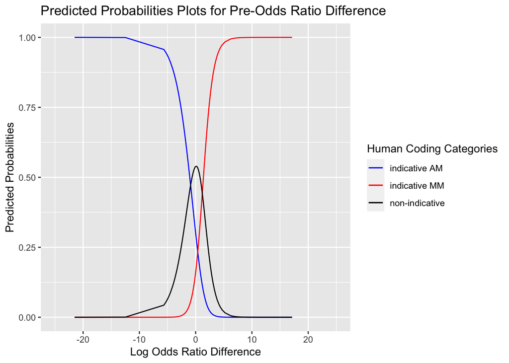

```r
prob_plot(am1_pm2_sub3_pre.mod, am1_pm2_sub3)
```

## AM1_PM3 (Down Sampled)

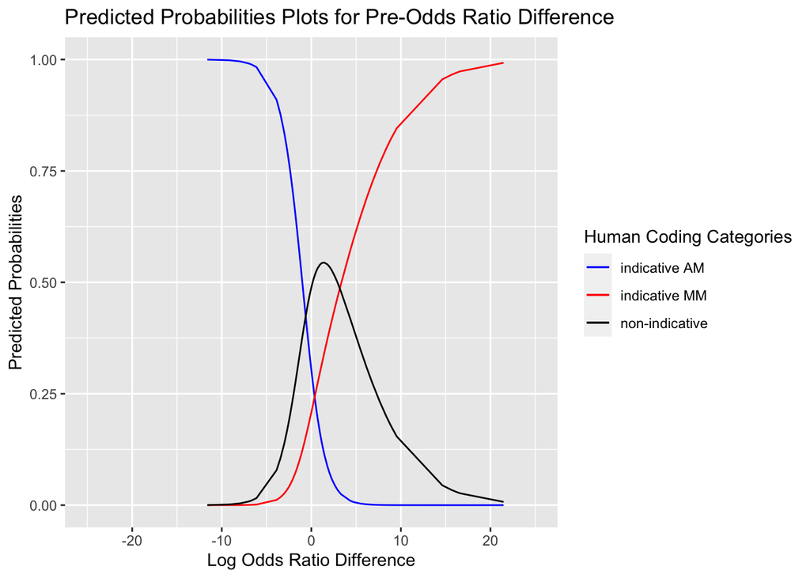

```r
prob_plot(am1_pm3_sub3_pre.mod, am1_pm3_sub3)
```

## AM2_PM1 (Down Sampled)

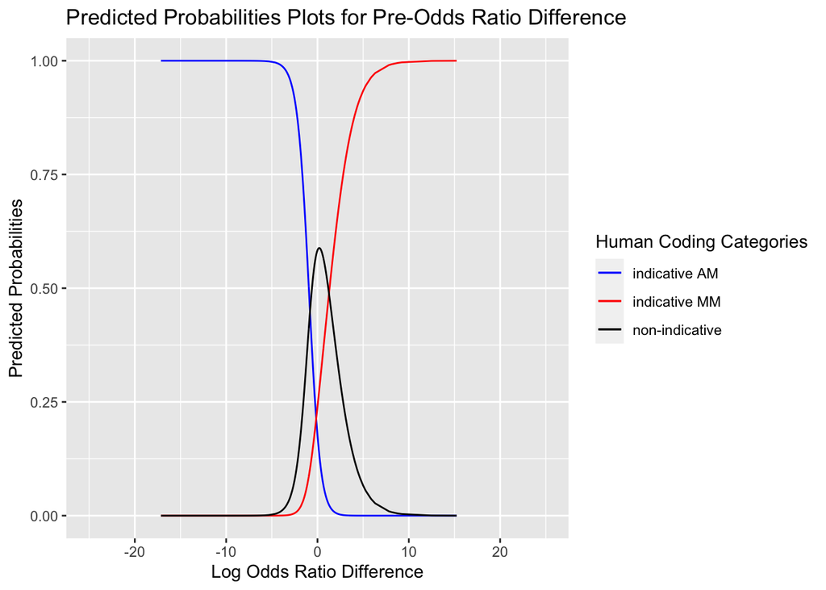

```r
prob_plot(am2_pm1_sub3_pre.mod, am2_pm1_sub3)
```

## AM2_PM3 (Down Sampled)

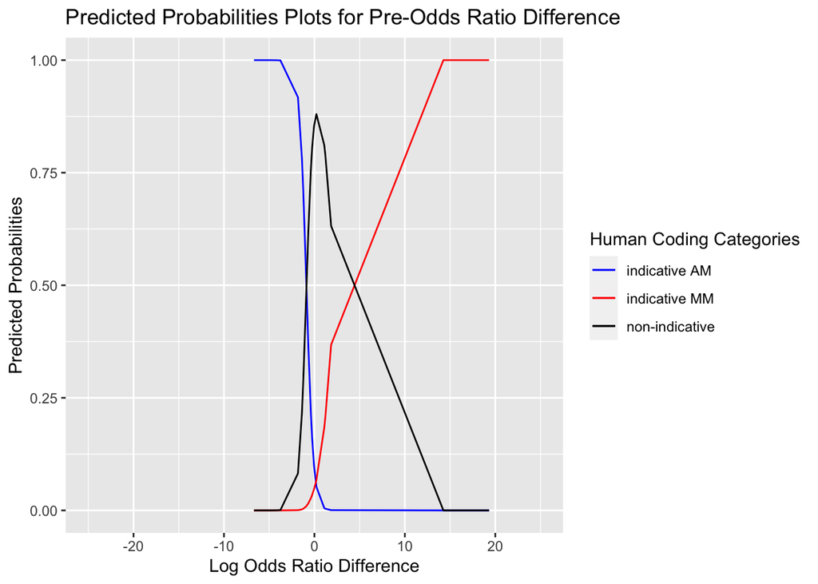

```r
prob_plot(am2_pm3_sub3_pre.mod, am2_pm3_sub3)
```

## AM3_PM1 (Down Sampled)

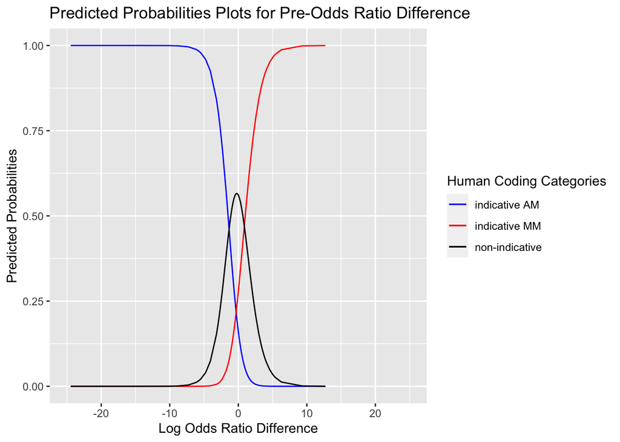

```r
prob_plot(am3_pm1_sub3_pre.mod, am3_pm1_sub3)
```

## AM3_PM2 (Down Sampled)

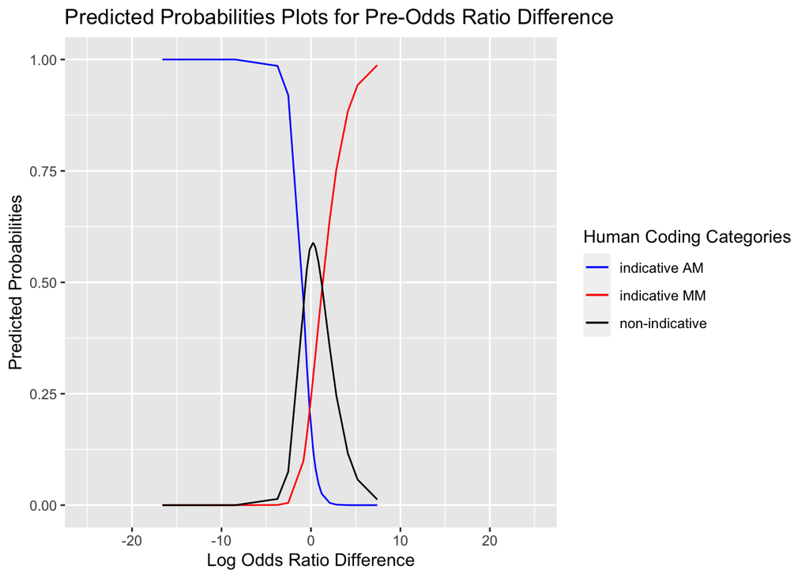

```r
prob_plot(am3_pm2_sub3_pre.mod, am3_pm2_sub3)
```

# 4. Model Performance (10 Fold Cross-Validation)

## AM1_PM2 (Down Sampled)

# Training

```r
am1_pm2_sub3_cm <- eval_train(am1_pm2_sub3)
t(am1_pm2_sub3_cm$table)
```

```
##                 Prediction
## Reference        indicative_AM indicative_MM non_indicative
##   indicative_AM             65             1             23
##   indicative_MM              1            74             14
##   non_indicative            11             9             69
```

```r
get_perform(t(am1_pm2_sub3_cm$table))
```

```
##                Precision    Recall  F1-Score
## Indicative-AM  0.8441558 0.7303371 0.7831325
## Indicative-MM  0.8809524 0.8314607 0.8554913
## Non-Indicative 0.6509434 0.7752809 0.7076923
```

# 10-Fold Cross Validation

```r
am1_pm2_sub3_cm_cv <- perform_10cv(am1_pm2_sub3, export = TRUE)
t(am1_pm2_sub3_cm_cv$table)
```

```
##                 Prediction
## Reference        indicative_AM indicative_MM non_indicative
##   indicative_AM             64             1             24
##   indicative_MM              1            72             16
##   non_indicative            12             9             68
```

```r
get_perform(t(am1_pm2_sub3_cm_cv$table))
```

```
##                Precision    Recall  F1-Score
## Indicative-AM  0.8311688 0.7191011 0.7710843
## Indicative-MM  0.8780488 0.8089888 0.8421053
## Non-Indicative 0.6296296 0.7640449 0.6903553
```

## AM1_PM3 (Down Sampled)

# Training

```r
am1_pm3_sub3_cm <- eval_train(am1_pm3_sub3)
t(am1_pm3_sub3_cm$table)
```

```
##                 Prediction
## Reference        indicative_AM indicative_MM non_indicative
##   indicative_AM             32             1             11
##   indicative_MM              0            26             18
##   non_indicative            14             4             26
```

```r
get_perform(t(am1_pm3_sub3_cm$table))
```

```
##                Precision    Recall  F1-Score
## Indicative-AM  0.6956522 0.7272727 0.7111111
## Indicative-MM  0.8387097 0.5909091 0.6933333
## Non-Indicative 0.4727273 0.5909091 0.5252525
```

# 10-Fold Cross Validation

```r
am1_pm3_sub3_cm_cv <- perform_10cv(am1_pm3_sub3, export = TRUE)
t(am1_pm3_sub3_cm_cv$table)
```

```
##                 Prediction
## Reference        indicative_AM indicative_MM non_indicative
##   indicative_AM             32             1             11
##   indicative_MM              0            25             19
##   non_indicative            14             4             26
```

```r
get_perform(t(am1_pm3_sub3_cm_cv$table))
```

```
##                Precision    Recall  F1-Score
## Indicative-AM  0.6956522 0.7272727 0.7111111
## Indicative-MM  0.8333333 0.5681818 0.6756757
## Non-Indicative 0.4642857 0.5909091 0.5200000
```

## AM2_PM1 (Down Sampled)

# Training

```r
am2_pm1_sub3_cm <- eval_train(am2_pm1_sub3)
t(am2_pm1_sub3_cm$table)
```

```
##                 Prediction
## Reference        indicative_AM indicative_MM non_indicative
##   indicative_AM             91             0             21
##   indicative_MM              4            80             28
##   non_indicative            14            20             78
```

```r
get_perform(t(am2_pm1_sub3_cm$table))
```

```
##                Precision    Recall  F1-Score
## Indicative-AM  0.8348624 0.8125000 0.8235294
## Indicative-MM  0.8000000 0.7142857 0.7547170
## Non-Indicative 0.6141732 0.6964286 0.6527197
```

# 10-Fold Cross Validation

```r
am2_pm1_sub3_cm_cv <- perform_10cv(am2_pm1_sub3, export = TRUE)
t(am2_pm1_sub3_cm_cv$table)
```

```
##                 Prediction
## Reference        indicative_AM indicative_MM non_indicative
##   indicative_AM             91             0             21
##   indicative_MM              4            81             27
##   non_indicative            15            20             77
```

```r
get_perform(t(am2_pm1_sub3_cm_cv$table))
```

```
##                Precision    Recall  F1-Score
## Indicative-AM  0.8272727 0.8125000 0.8198198
## Indicative-MM  0.8019802 0.7232143 0.7605634
## Non-Indicative 0.6160000 0.6875000 0.6497890
```

## AM2_PM3 (Down Sampled)

# Training

```r
am2_pm3_sub3_cm <- eval_train(am2_pm3_sub3)
t(am2_pm3_sub3_cm$table)
```

```
##                 Prediction
## Reference        indicative_AM indicative_MM non_indicative
##   indicative_AM              7             0              1
##   indicative_MM              0             7              1
##   non_indicative             1             0              7
```

```r
get_perform(t(am2_pm3_sub3_cm$table))
```

```
##                Precision Recall  F1-Score
## Indicative-AM  0.8750000  0.875 0.8750000
## Indicative-MM  1.0000000  0.875 0.9333333
## Non-Indicative 0.7777778  0.875 0.8235294
```

# 10-Fold Cross Validation

```r
am2_pm3_sub3_cm_cv <- perform_10cv(am2_pm3_sub3, export = TRUE)
t(am2_pm3_sub3_cm_cv$table)
```

```
##                 Prediction
## Reference        indicative_AM indicative_MM non_indicative
##   indicative_AM              6             0              2
##   indicative_MM              0             7              1
##   non_indicative             1             1              6
```

```r
get_perform(t(am2_pm3_sub3_cm_cv$table))
```

```
##                Precision Recall  F1-Score
## Indicative-AM  0.8571429  0.750 0.8000000
## Indicative-MM  0.8750000  0.875 0.8750000
## Non-Indicative 0.6666667  0.750 0.7058824
```

## AM3_PM1 (Down Sampled)

# Training

```r
am3_pm1_sub3_cm <- eval_train(am3_pm1_sub3)
t(am3_pm1_sub3_cm$table)
```

```
##                 Prediction
## Reference        indicative_AM indicative_MM non_indicative
##   indicative_AM             44             0             18
##   indicative_MM              1            45             16
##   non_indicative             4            15             43
```

```r
get_perform(t(am3_pm1_sub3_cm$table))
```

```
##                Precision    Recall  F1-Score
## Indicative-AM  0.8979592 0.7096774 0.7927928
## Indicative-MM  0.7500000 0.7258065 0.7377049
## Non-Indicative 0.5584416 0.6935484 0.6187050
```

# 10-Fold Cross Validation

```r
am3_pm1_sub3_cm_cv <- perform_10cv(am3_pm1_sub3, export = TRUE)
t(am3_pm1_sub3_cm_cv$table)
```

```
##                 Prediction
## Reference        indicative_AM indicative_MM non_indicative
##   indicative_AM             44             0             18
##   indicative_MM              1            46             15
##   non_indicative             6            15             41
```

```r
get_perform(t(am3_pm1_sub3_cm_cv$table))
```

```
##                Precision    Recall  F1-Score
## Indicative-AM  0.8627451 0.7096774 0.7787611
## Indicative-MM  0.7540984 0.7419355 0.7479675
## Non-Indicative 0.5540541 0.6612903 0.6029412
```

## AM3_PM2 (Down Sampled)

# Training

```r
am3_pm2_sub3_cm <- eval_train(am3_pm2_sub3)
t(am3_pm2_sub3_cm$table)
```

```
##                 Prediction
## Reference        indicative_AM indicative_MM non_indicative
##   indicative_AM              7             0              2
##   indicative_MM              0             8              1
##   non_indicative             1             0              8
```

```r
get_perform(t(am3_pm2_sub3_cm$table))
```

```
##                Precision    Recall  F1-Score
## Indicative-AM  0.8750000 0.7777778 0.8235294
## Indicative-MM  1.0000000 0.8888889 0.9411765
## Non-Indicative 0.7272727 0.8888889 0.8000000
```

# 10-Fold Cross Validation

```r
am3_pm2_sub3_cm_cv <- perform_10cv(am3_pm2_sub3, export = TRUE)
t(am3_pm2_sub3_cm_cv$table)
```

```
##                 Prediction
## Reference        indicative_AM indicative_MM non_indicative
##   indicative_AM              8             0              1
##   indicative_MM              0             8              1
##   non_indicative             1             1              7
```

```r
get_perform(t(am3_pm2_sub3_cm_cv$table))
```

```
##                Precision    Recall  F1-Score
## Indicative-AM  0.8888889 0.8888889 0.8888889
## Indicative-MM  0.8888889 0.8888889 0.8888889
## Non-Indicative 0.7777778 0.7777778 0.7777778
```